# Coursework Report

*N* removed NAs: 3

*N* removed typo: 1

*N* removed <18: 26

*N* total clean: 120

| Group | *N* | *M*<sub>age</sub> | *M*<sub>rating</sub> |
| --- | --- | --- | --- |
| Control | 56 | 20.68 | 6.71 |
| Experim | 64 | 20.73 | 6.14 |

**Main analysis results**

*t*(118) = 3.86, *p* < .001

[interactive chart not shown]

[figure not shown]

[interactive chart not shown]

# Coursework Report

Analysing Data, Spring 2020

```
## .
## 11 13 14 15 16 17 18 19 1i 20 21 22 23 24 25 26 27
##  1  1  3  3  9  9 20 20  1 23 17 17 10  5  5  2  1
```

```
## # A tibble: 150 x 6
##    ID_CODE AGE_YEARS GROUP        ITEM_1 ITEM_2 ITEM_3
##    <fct>   <chr>     <fct>         <dbl>  <dbl>  <dbl>
##  1 HRTT    20        experimental      8      7      6
##  2 YPWK    22        experimental      7      6      5
##  3 WWYZ    <NA>      experimental      7      6      4
##  4 UJDM    24        experimental      5      8      7
##  5 BIFN    20        experimental      6      7      7
##  6 DJEA    21        experimental      8      6      7
##  7 JTCL    21        experimental      3      6      7
##  8 VFFK    21        experimental      7      7      7
##  9 XHBK    19        experimental      7      8      6
## 10 FLTN    22        experimental      4      7      7
## # ... with 140 more rows
```

```
## .
##  1 11 13 14 15 16 17 18 19 20 21 22 23 24 25 26 27
##  1  1  1  3  3  9  9 20 20 23 17 17 10  5  5  2  1
```

```
## # A tibble: 150 x 6
##    ID_CODE AGE_YEARS GROUP        ITEM_1 ITEM_2 ITEM_3
##    <fct>       <dbl> <fct>         <dbl>  <dbl>  <dbl>
##  1 HRTT           20 experimental      8      7      6
##  2 YPWK           22 experimental      7      6      5
##  3 WWYZ           NA experimental      7      6      4
##  4 UJDM           24 experimental      5      8      7
##  5 BIFN           20 experimental      6      7      7
##  6 DJEA           21 experimental      8      6      7
##  7 JTCL           21 experimental      3      6      7
##  8 VFFK           21 experimental      7      7      7
##  9 XHBK           19 experimental      7      8      6
## 10 FLTN           22 experimental      4      7      7
## # ... with 140 more rows
```

```
## [1] "numeric"
```

```
## .
##      control experimental  expermental
##           73           76            1
```

```
## # A tibble: 150 x 6
##    ID_CODE AGE_YEARS GROUP        ITEM_1 ITEM_2 ITEM_3
##    <fct>       <dbl> <fct>         <dbl>  <dbl>  <dbl>
##  1 HRTT           20 experimental      8      7      6
##  2 YPWK           22 experimental      7      6      5
##  3 WWYZ           NA experimental      7      6      4
##  4 UJDM           24 experimental      5      8      7
##  5 BIFN           20 experimental      6      7      7
##  6 DJEA           21 experimental      8      6      7
##  7 JTCL           21 experimental      3      6      7
##  8 VFFK           21 experimental      7      7      7
##  9 XHBK           19 experimental      7      8      6
## 10 FLTN           22 experimental      4      7      7
## # ... with 140 more rows
```

```
## .
##      control experimental
##           73           77
```

```
## # A tibble: 150 x 6
##    ID_CODE AGE_YEARS GROUP        ITEM_1 ITEM_2 ITEM_3
##    <fct>       <dbl> <fct>         <dbl>  <dbl>  <dbl>
##  1 HRTT           20 experimental      8      7      6
##  2 YPWK           22 experimental      7      6      5
##  3 WWYZ           NA experimental      7      6      4
##  4 UJDM           24 experimental      5      8      7
##  5 BIFN           20 experimental      6      7      7
##  6 DJEA           21 experimental      8      6      7
##  7 JTCL           21 experimental      3      6      7
##  8 VFFK           21 experimental      7      7      7
##  9 XHBK           19 experimental      7      8      6
## 10 FLTN           22 experimental      4      7      7
## # ... with 140 more rows
```

```
## [1] "factor"
```

```
##     ID_CODE      AGE_YEARS              GROUP        ITEM_1          ITEM_2          ITEM_3
##  AEBS   :  1   Min.   : 1.00   control     :73   Min.   :2.000   Min.   :1.000   Min.   :3.00
##  AFLV   :  1   1st Qu.:18.00   experimental:77   1st Qu.:6.000   1st Qu.:6.000   1st Qu.:5.25
##  AMBB   :  1   Median :20.00                     Median :6.000   Median :7.000   Median :6.00
##  ASSH   :  1   Mean   :19.69                     Mean   :6.393   Mean   :6.527   Mean   :6.32
##  AXXC   :  1   3rd Qu.:22.00                     3rd Qu.:7.000   3rd Qu.:7.000   3rd Qu.:7.00
##  AYBE   :  1   Max.   :27.00                     Max.   :9.000   Max.   :9.000   Max.   :9.00
##  (Other):144   NA's   :3
```

```
## [1] 27
```

```
## # A tibble: 120 x 6
##    ID_CODE AGE_YEARS GROUP ITEM_1 ITEM_2 ITEM_3
##    <lgl>   <lgl>     <lgl> <lgl>  <lgl>  <lgl>
##  1 FALSE   FALSE     FALSE FALSE  FALSE  FALSE
##  2 FALSE   FALSE     FALSE FALSE  FALSE  FALSE
##  3 FALSE   FALSE     FALSE FALSE  FALSE  FALSE
##  4 FALSE   FALSE     FALSE FALSE  FALSE  FALSE
##  5 FALSE   FALSE     FALSE FALSE  FALSE  FALSE
##  6 FALSE   FALSE     FALSE FALSE  FALSE  FALSE
##  7 FALSE   FALSE     FALSE FALSE  FALSE  FALSE
##  8 FALSE   FALSE     FALSE FALSE  FALSE  FALSE
##  9 FALSE   FALSE     FALSE FALSE  FALSE  FALSE
## 10 FALSE   FALSE     FALSE FALSE  FALSE  FALSE
## # ... with 110 more rows
```

[output not shown]

```
## [1] 0
```

```
## # A tibble: 1 x 4
##    mean    sd   min   max
##   <dbl> <dbl> <dbl> <dbl>
## 1  20.7  2.13    18    27
```

```
## # A tibble: 1 x 4
##    mean    sd   min   max
##   <dbl> <dbl> <dbl> <dbl>
## 1  6.41  1.45     2     9
```

```
## # A tibble: 1 x 4
##    mean    sd   min   max
##   <dbl> <dbl> <dbl> <dbl>
## 1  6.53  1.48     1     9
```

```
## # A tibble: 1 x 4
##    mean    sd   min   max
##   <dbl> <dbl> <dbl> <dbl>
## 1  6.28  1.37     3     9
```

```
## # A tibble: 120 x 7
## # Groups:   ID_CODE [120]
##    ID_CODE AGE_YEARS GROUP        ITEM_1 ITEM_2 ITEM_3 attract_mean
##    <fct>       <dbl> <fct>         <dbl>  <dbl>  <dbl>        <dbl>
##  1 HRTT           20 experimental      8      7      6         7
##  2 YPWK           22 experimental      7      6      5         6
##  3 UJDM           24 experimental      5      8      7         6.67
##  4 BIFN           20 experimental      6      7      7         6.67
##  5 DJEA           21 experimental      8      6      7         7
##  6 JTCL           21 experimental      3      6      7         5.33
##  7 VFFK           21 experimental      7      7      7         7
##  8 XHBK           19 experimental      7      8      6         7
##  9 FLTN           22 experimental      4      7      7         6
## 10 HQRW           19 experimental      5      6      4         5
## # ... with 110 more rows
```

```
## # A tibble: 1 x 4
##    mean    sd   min   max
##   <dbl> <dbl> <dbl> <dbl>
## 1  6.41  0.86     4  8.33
```

```
## # A tibble: 1 x 4
##   mean_AGE_YEARS sd_AGE_YEARS min_AGE_YEARS max_AGE_YEARS
##            <dbl>        <dbl>         <dbl>         <dbl>
## 1           20.7         2.13            18            27
```

| ITEM_1 | n | perc | mean_AGE_YEARS | sd_AGE_YEARS |
| --- | --- | --- | --- | --- |
| 2 | 1 | 0.83 | 26.00 | NA |
| 3 | 4 | 3.33 | 20.25 | 1.50 |
| 4 | 6 | 5.00 | 19.50 | 1.52 |
| 5 | 15 | 12.50 | 20.93 | 2.28 |
| 6 | 36 | 30.00 | 20.58 | 2.12 |
| 7 | 33 | 27.50 | 20.55 | 2.18 |
| 8 | 16 | 13.33 | 21.25 | 2.27 |
| 9 | 9 | 7.50 | 20.89 | 1.54 |

Table 1 *Descriptive statistics by Item 1*

[output not shown]

| ITEM_2 | n | perc | mean_AGE_YEARS | sd_AGE_YEARS |
| --- | --- | --- | --- | --- |
| 1 | 1 | 0.83 | 21.00 | NA |
| 3 | 3 | 2.50 | 20.67 | 1.53 |
| 4 | 5 | 4.17 | 20.80 | 2.59 |
| 5 | 17 | 14.17 | 20.24 | 2.14 |
| 6 | 29 | 24.17 | 20.55 | 2.28 |
| 7 | 35 | 29.17 | 20.49 | 2.02 |
| 8 | 20 | 16.67 | 21.65 | 2.35 |
| 9 | 10 | 8.33 | 20.80 | 1.62 |

Table 2 *Descriptive statistics by Item 2*

[output not shown]

| ITEM_3 | n | perc | mean_AGE_YEARS | sd_AGE_YEARS |
| --- | --- | --- | --- | --- |
| 3 | 2 | 1.67 | 22.00 | 4.24 |
| 4 | 12 | 10.00 | 20.58 | 2.54 |
| 5 | 18 | 15.00 | 20.72 | 2.16 |
| 6 | 32 | 26.67 | 20.38 | 2.00 |
| 7 | 37 | 30.83 | 21.00 | 1.97 |
| 8 | 12 | 10.00 | 21.17 | 2.55 |
| 9 | 7 | 5.83 | 19.71 | 1.70 |

Table 3 *Descriptive statistics by Item 3*

[output not shown]

| attract_mean | n | perc | mean_AGE_YEARS | sd_AGE_YEARS |
| --- | --- | --- | --- | --- |
| 4.00 | 1 | 0.83 | 22.00 | NA |
| 4.33 | 2 | 1.67 | 19.50 | 0.71 |
| 4.67 | 1 | 0.83 | 21.00 | NA |
| 5.00 | 6 | 5.00 | 20.67 | 2.88 |
| 5.33 | 7 | 5.83 | 20.43 | 1.90 |
| 5.67 | 15 | 12.50 | 20.13 | 2.64 |
| 6.00 | 12 | 10.00 | 20.92 | 2.27 |
| 6.33 | 18 | 15.00 | 20.72 | 2.42 |
| 6.67 | 14 | 11.67 | 20.57 | 1.60 |
| 7.00 | 24 | 20.00 | 20.96 | 2.05 |
| 7.33 | 10 | 8.33 | 21.40 | 2.41 |
| 7.67 | 6 | 5.00 | 20.33 | 1.86 |
| 8.00 | 2 | 1.67 | 21.50 | 0.71 |
| 8.33 | 2 | 1.67 | 20.00 | 1.41 |

Table 4 *Descriptive statistics by Attract Mean*

[output not shown]

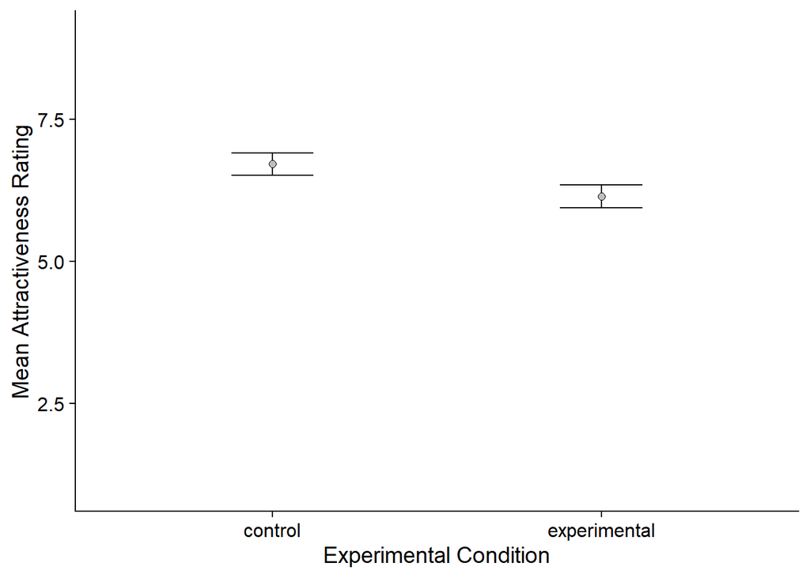

```
##
##  Two Sample t-test
##
## data:  attract_mean by GROUP
## t = 3.8603, df = 118, p-value = 0.0001853
## alternative hypothesis: true difference in means is not equal to 0
## 95 percent confidence interval:
##  0.2793792 0.8679422
## sample estimates:
##      mean in group control mean in group experimental
##                   6.714286                   6.140625
```

# Methods

## Design

The conceptual hypothesis was, does colour influence attractiveness? The independent variable in the study was what colour participants viewed in the frame, as it was either red or white. The operationalisation for the independent variable were participants in the control condition would view a white frame and in the experimental condition a red frame. This independent variable would be the factor we are manipulating and is categorical. The dependent variable in the study were the ratings on three questions after reviewing the picture in a frame. The operationalisation for the dependent variable was the rating scale being 1-9 and three questions with the first question being, ‘how attractive do you think the person was?’, the 2nd being ‘how pleasant is this person to look at?’ and the 3rd being ‘if I were to meet the person face to face, I would think he is attractive.’ The answers given then were averaged to get a composite score. This continuous dependent variable would be the rating that changes depending on the manipulation of the independent variable. The interpretation of the dependent variable would be if participants rate the image at a 1, it is viewed as the lowest level of attraction. In contrast, if the participant rates the image at a 9, that is the highest level of attraction. The operational hypothesis was, does viewing a different colour frame around an image of a moderately attractive man influence the mean ratings of his attractiveness? The statistical test we will use to check whether our results are meaningful will be a t-test.

# Results

The pattern of results in the experiment conveyed participants rating the male more attractive in the white colour frame (control) than they did in the red colour frame (experimental). In item 1 the mean rating for the control condition was 6.57 with a standard deviation of 1.38. In the experimental condition for this item, the mean rating was 6.26 with a standard deviation 1.49. This displays rating was higher in the control condition when asked the question ‘how attractive do you think the person was?’. The standard deviation displays more precise results for the control condition, having a standard deviation of 1.38.

In item 2 the mean rating for the control condition was 7.01 with a standard deviation of 1.31. In the experimental condition for this item, the mean rating was 6.10 with a standard deviation of 1.49. Once again, the findings portray a higher mean rating for the control condition when asked the question, ‘how pleasant is this person to look at?’, as the mean rating was 7.01 compared to 6.10. The standard deviation was also less in the control condition, displaying less difference in the mean value.

In item 3 the mean rating for the control condition was 6.55 with a standard deviation of 1.30. In the experimental condition for this item the mean rating was 6.04 with a standard deviation of 1.38. The results in item 3 convey the persistent finding in which participants rate the male higher in the control condition than the experimental, as the mean in the control was 6.55 compared to 6.04. The standard deviation was also less in the control (1.30) than the experimental (1.38).

# Discussion

The findings of the present research support our two-tailed hypothesis as there was a consistent higher attractive rating in one condition compared to the other. However, the results did not support our prediction as the higher attractive rating was for the control condition (white frame), rather than the experimental condition (red frame). The findings in the present study are different to that of the original study, as in the original study (Elliot, 2010) the attractiveness ratings were higher in the experimental condition than the control condition. One main difference between the present research and the initial research is the original study used a blue colour in the control condition compared to a white colour used in ours. An interesting point for future research could be investigating if the effect varies colour to colour, as some colour’s may be more efficient in aiding attraction ratings compared to others. This was evident in our study as the control condition (white) was more efficient in producing higher attractiveness ratings than the experimental (red). Although this didn’t apply in Elliot et al (2010) study when having a blue colour rather than a white.

Another study (Haran, 2016) tried to replicate the findings in Elliot et al (2010). The findings in Haran’s study (2016) found no significant interaction between colour and perceived attractiveness. This was also apparent in Hesslinger et al (2015) study, whereby they tried to replicate the findings of those in Elliot et al (2010), but found no significant relation between colour and perceived attractiveness. In our research, we did not find the same pattern of results in all 3 different studies discussed. However, we did find similarities to that of Elliot et al (2010), as we found significance for the relation between colour and perceived attraction. Although the relation was between the colour white and not the colour red. This suggests there is a potentiality for a relation between colour and perceived attractiveness, as multiple studies got a variety of results. Due to the uncertainty of results more research would be needed on this research question to understand if there is an apparent effect.

Based off the evidence in our study and other studies which tried to replicate Elliot et al (2010) study, I believe the effect isn’t strong but it doesn’t mean it’s not apparent. Multiple studies reached different conclusions and therefore allowed uncertainty around this research question. I suggest the effect may be in a variety of colour’s and not just the colour red, as in our present findings there is a significant effect, but for the colour white and not red. Therefore, I believe this theory is worth investigating more. I suggest for future research to investigate a variety of colour’s as the effect may not just be with the colour red, but could also be with other colour’s.

Overall, in the present study there is significance in colour affecting perceived attractiveness, however different to that of the Elliot et al study (2010), as our colour of significance was white not red. I suggest for future research to conform to strict measures to allow for reliable testing, as Elliot et al (2010) has suffered from reproducibility. To understand whether this effect is apparent more research is needed. After understanding whether this effect is credible, future research could delve into more colour’s to understand whether different colour’s and perceived attractiveness is apparent. Especially as our study found significance in the colour white for perceived attractiveness, suggesting there could be other colour’s, as well as the colour white.

# References

Elliot, A.J., Niesta Kayser, D., Greitemeyer, T., Lichtenfeld, S., Gramzow, R.H., Maier, M.A. and Liu, H., 2010. Red, rank, and romance in women viewing men. Journal of Experimental Psychology: General, 139(3), p.399.

Haran, K. and Briggs, S.G., 2016. Red, Rank, and Romance in Women viewing Men. UC Merced Undergraduate Research Journal, 8(2).

Hesslinger, V.M., Goldbach, L. and Carbon, C.C., 2015. Men in red: A reexamination of the red-attractiveness effect. Psychonomic bulletin & review, 22(4), pp.1142-1148.